# Homework Project A

Waheeb Algabri, William Berritt, Kossi Akplaka

### Introduction

In today’s data-driven world, the ability to forecast accurately is crucial for strategic planning and decision-making. This project aims to harness the power of historical data to generate reliable forecasts for various series within a de-identified dataset. With a comprehensive dataset spanning 1622 periods, we will employ advanced data analysis and forecasting techniques to predict future trends for the next 140 periods.

This report is crafted to cater to a diverse audience, ranging from individuals with no background in data science to seasoned data scientists. Our goal is to present the analysis and findings in a clear, concise, and accessible manner. We will explain the methodologies used, the rationale behind their selection, and the step-by-step process of our analysis, ensuring transparency and comprehensibility for all readers.

The report is structured to balance technical rigor with simplicity, providing a thorough yet comprehensible narrative of our forecasting journey. We begin with an exploration of the data, followed by a detailed explanation of the forecasting methods applied, and conclude with the results and their implications. Visualizations and key insights will be highlighted to enhance understanding and readability.

By leveraging fundamental techniques, thorough data exploration, and robust forecasting methods, this project not only aims to achieve high accuracy in predictions but also to demonstrate the importance of effective communication in data science. The accompanying Excel workbook will include the forecasted values for each category, organized systematically to facilitate error rate calculations and further analysis.

Loading necessary Packages

### Data exploration

Read the excel file and extract the data

using glimpse, so we can view the attributes of our dataset

```
## Rows: 10,572
## Columns: 7
## $ SeriesInd <dbl> 40669, 40669, 40669, 40669, 40669, 40669, 40670, 40670, 4067…
## $ category  <chr> "S03", "S02", "S01", "S06", "S05", "S04", "S03", "S02", "S01…
## $ Var01     <dbl> 30.64286, 10.28000, 26.61000, 27.48000, 69.26000, 17.20000, …
## $ Var02     <dbl> 123432400, 60855800, 10369300, 39335700, 27809100, 16587400,…
## $ Var03     <dbl> 30.34000, 10.05000, 25.89000, 26.82000, 68.19000, 16.88000, …
## $ Var05     <dbl> 30.49000, 10.17000, 26.20000, 27.02000, 68.72000, 16.94000, …
## $ Var07     <dbl> 30.57286, 10.28000, 26.01000, 27.32000, 69.15000, 17.10000, …
```

Dataset have 10,572 rows and 7 columns.

First 6 Rows of Data

| SeriesInd | category | Var01 | Var02 | Var03 | Var05 | Var07 |
| --- | --- | --- | --- | --- | --- | --- |
| 40669 | S03 | 30.64286 | 123432400 | 30.34 | 30.49 | 30.57286 |
| 40669 | S02 | 10.28000 | 60855800 | 10.05 | 10.17 | 10.28000 |
| 40669 | S01 | 26.61000 | 10369300 | 25.89 | 26.20 | 26.01000 |
| 40669 | S06 | 27.48000 | 39335700 | 26.82 | 27.02 | 27.32000 |
| 40669 | S05 | 69.26000 | 27809100 | 68.19 | 68.72 | 69.15000 |
| 40669 | S04 | 17.20000 | 16587400 | 16.88 | 16.94 | 17.10000 |

check if there are any missing values in the entire dataframe

```
## [1] TRUE
```

count the number of missing values in the entire dataframe

```
## [1] 4294
```

Make sure if there is more missing values

```
## [1] 0
```

In order to forecast each variable within each group, we needed to break the larger dataset into its individual groups so we could perform our analysis and properly visualize our data.

### Data Preparation

**Split Data into Categories**

Separate the data into six sheets based on the category column.

**Sort Each Sheet by SeriesInd**

### Exploratory Data Analysis (EDA)

```
##    SeriesInd       category             Var01            Var02
##  Min.   :40669   Length:10572       Min.   :  9.03   Min.   :  1339900
##  1st Qu.:41303   Class :character   1st Qu.: 25.40   1st Qu.: 13073675
##  Median :41946   Mode  :character   Median : 43.60   Median : 23453700
##  Mean   :41945                      Mean   : 46.98   Mean   : 37035741
##  3rd Qu.:42587                      3rd Qu.: 61.34   3rd Qu.: 39322325
##  Max.   :43221                      Max.   :195.18   Max.   :480879500
##      Var03            Var05            Var07
##  Min.   :  8.82   Min.   :  8.99   Min.   :  8.92
##  1st Qu.: 24.65   1st Qu.: 25.05   1st Qu.: 24.99
##  Median : 42.91   Median : 43.29   Median : 43.28
##  Mean   : 46.12   Mean   : 46.55   Mean   : 46.56
##  3rd Qu.: 60.30   3rd Qu.: 60.83   3rd Qu.: 60.89
##  Max.   :189.36   Max.   :195.00   Max.   :189.72
```

Visualization

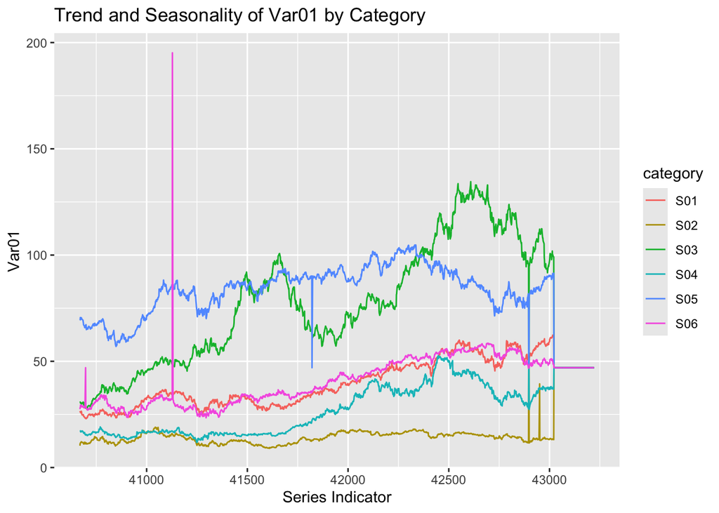

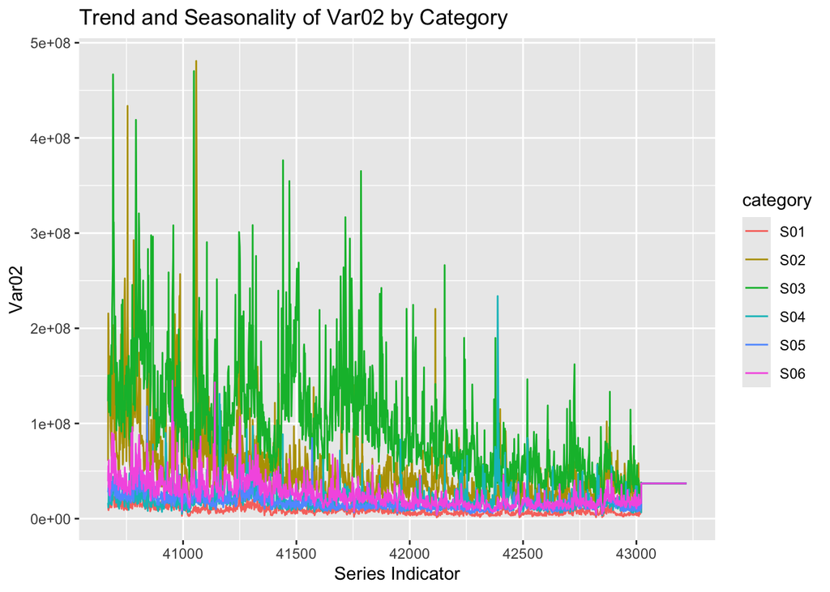

[figure not shown]

[figure not shown]

[figure not shown]

### Methodology:

we chose ARIMA beacuse the AutoRegressive Integrated Moving Average (ARIMA) model is a popular and flexible method for time series forecasting. ARIMA models account for various patterns in the data, such as trends and seasonality, making them suitable for our analysis. We use ARIMA because it is well-suited for univariate time series forecasting, where the future value of a variable is predicted based on its own past values.

### Forecasts

#### S01: Forecast Var01, Var02

##### Forecast Var01:

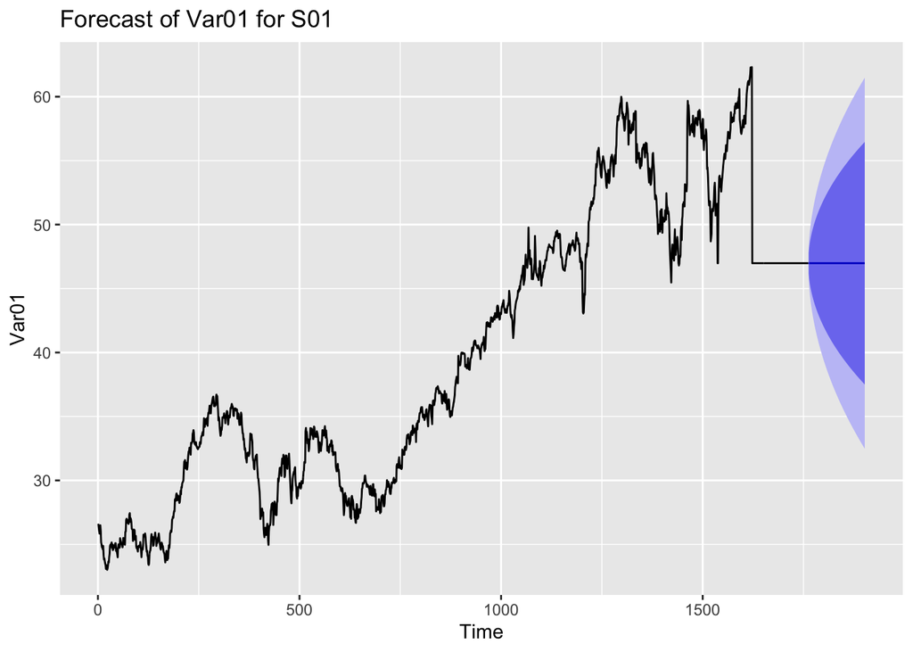

##### Forecast Var02:

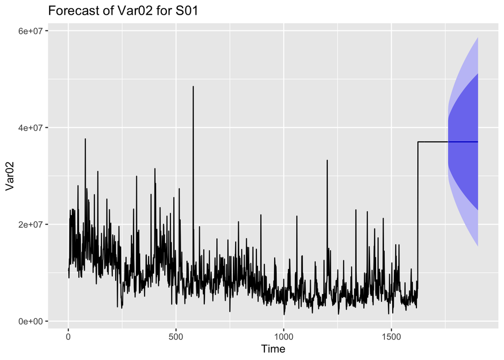

#### S02: Forecast Var02, Var03

##### Forecast Var02:

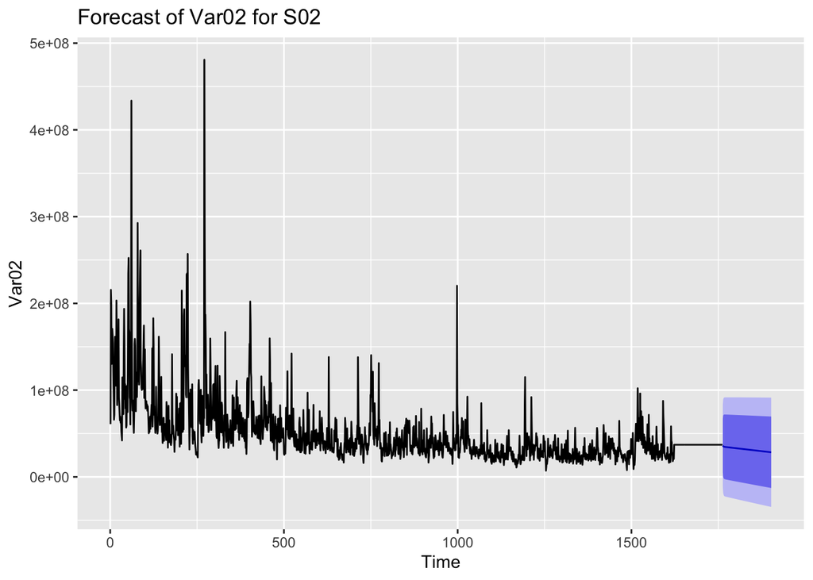

##### Forecast Var03:

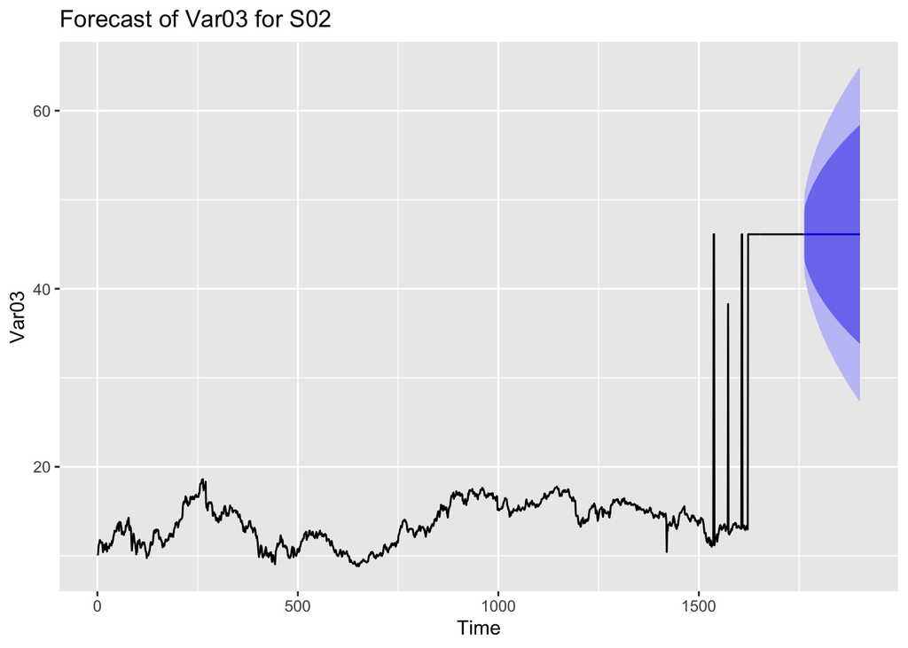

#### S03: Forecast Var05, Var07

##### Forecast Var05

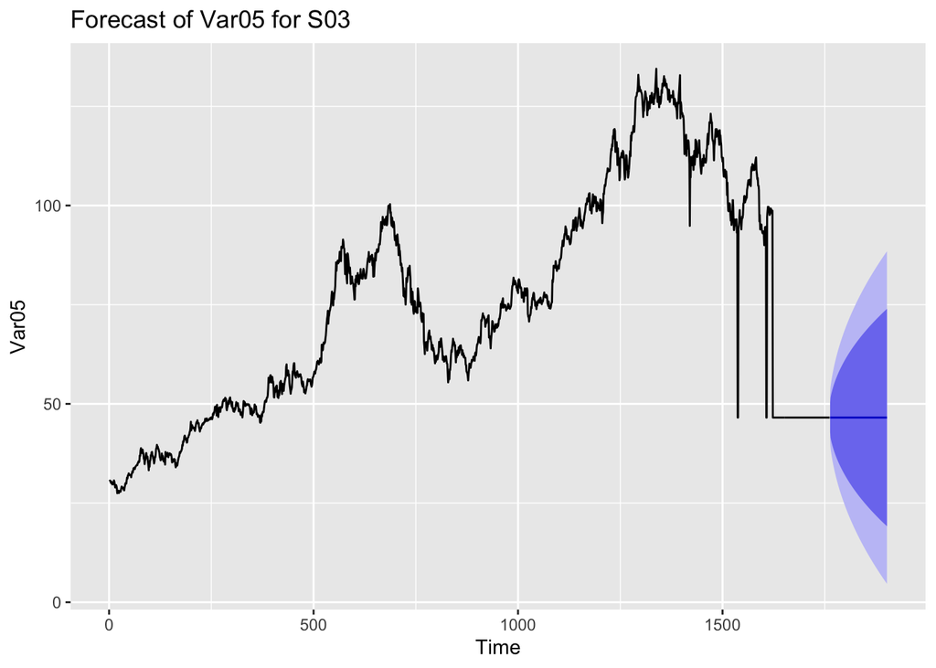

##### Forecast Var07

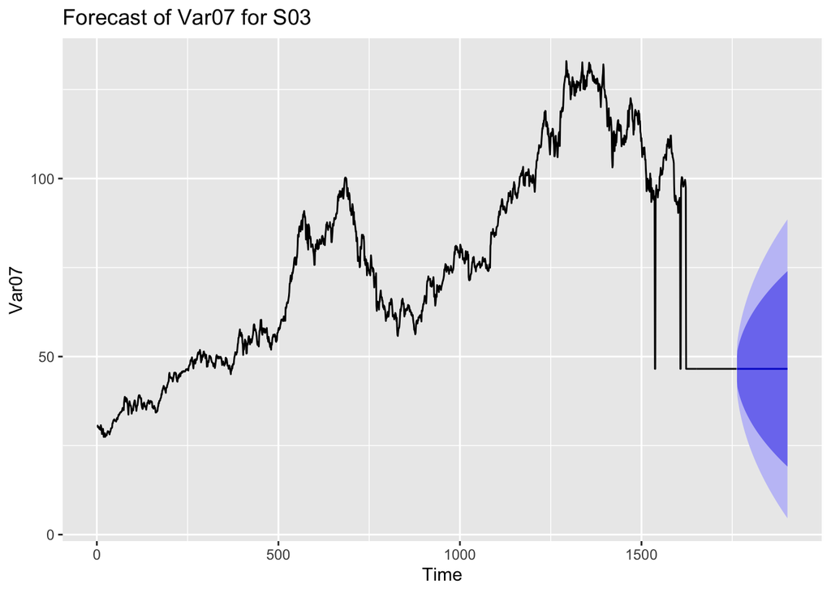

#### S04: Forecast Var01, Var02

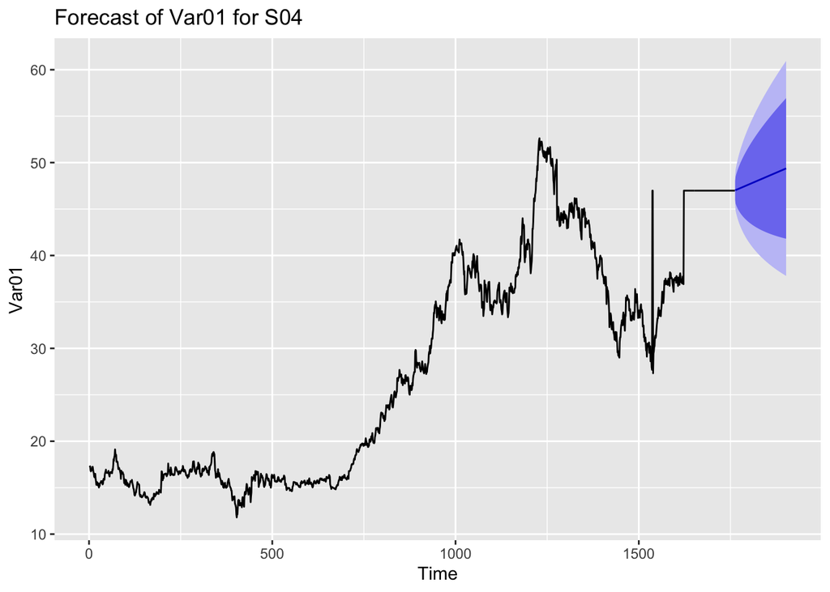

##### Forecast Var02:

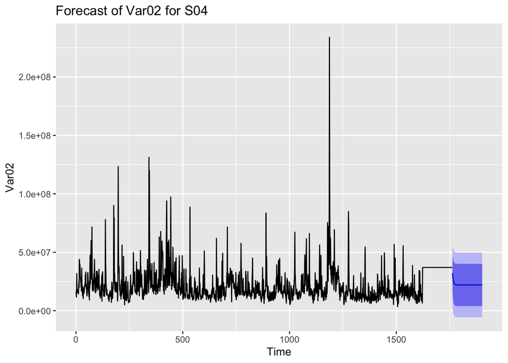

#### S05: Forecast Var02, Var03

##### Forecast Var02:

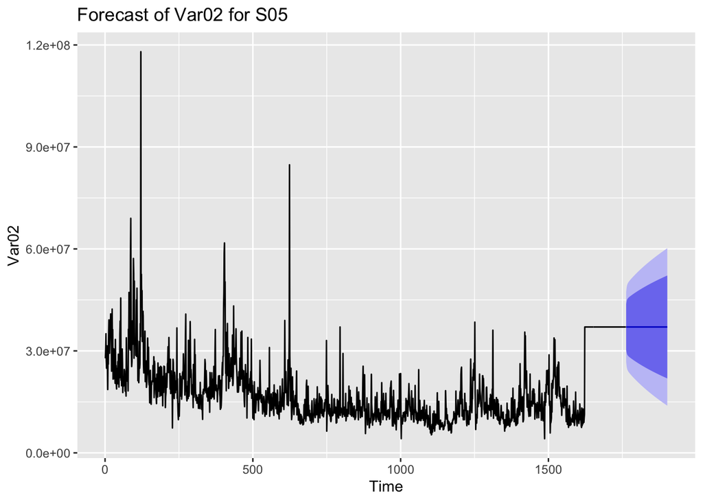

##### Forecast Var03:

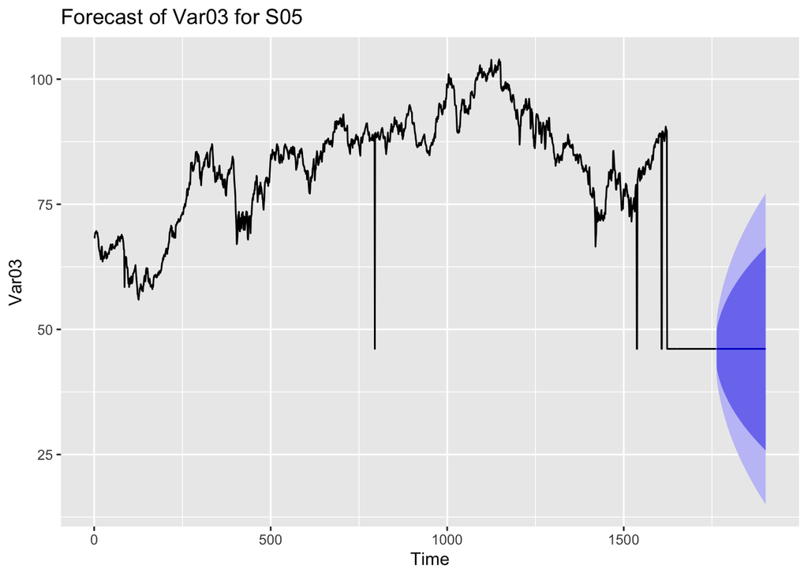

#### S06: Forecast Var05, Var07

##### Forecast Var05:

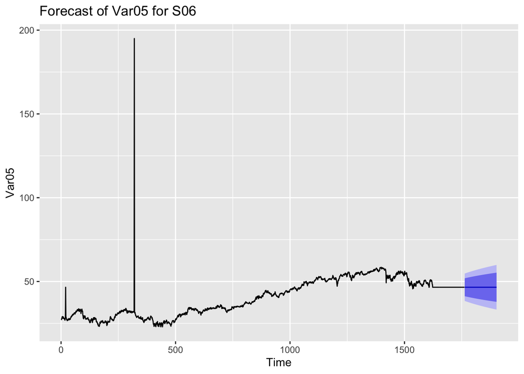

##### Forecast Var07:

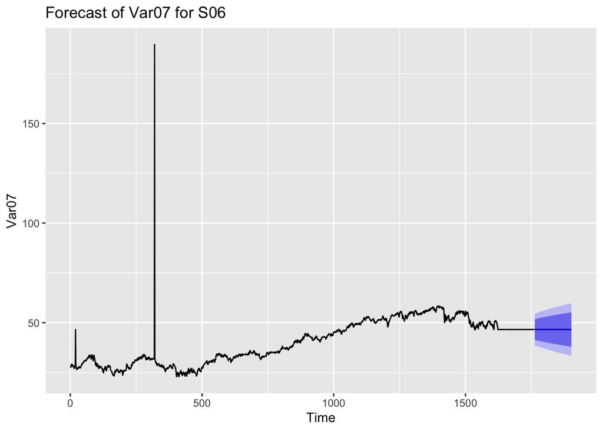

## Data

[output not shown]

[output not shown]

[output not shown]

```
## # A tibble: 6 × 7
##   SeriesInd category Var01     Var02 Var03 Var05 Var07
##       <dbl> <chr>    <dbl>     <dbl> <dbl> <dbl> <dbl>
## 1     40669 S03       30.6 123432400  30.3  30.5  30.6
## 2     40669 S02       10.3  60855800  10.0  10.2  10.3
## 3     40669 S01       26.6  10369300  25.9  26.2  26.0
## 4     40669 S06       27.5  39335700  26.8  27.0  27.3
## 5     40669 S05       69.3  27809100  68.2  68.7  69.2
## 6     40669 S04       17.2  16587400  16.9  16.9  17.1
```

```
## # A tibble: 6 × 7
##   SeriesInd category Var01     Var02 Var03 Var05 Var07
##       <dbl> <chr>    <dbl>     <dbl> <dbl> <dbl> <dbl>
## 1     43221 S03       47.0 37035741.  46.1  46.6  46.6
## 2     43221 S02       47.0 37035741.  46.1  46.6  46.6
## 3     43221 S01       47.0 37035741.  46.1  46.6  46.6
## 4     43221 S06       47.0 37035741.  46.1  46.6  46.6
## 5     43221 S05       47.0 37035741.  46.1  46.6  46.6
## 6     43221 S04       47.0 37035741.  46.1  46.6  46.6
```

[output not shown]

[output not shown]

[output not shown]

[output not shown]

[output not shown]

[output not shown]

[output not shown]

[output not shown]

[output not shown]

[output not shown]

[output not shown]

[output not shown]

[output not shown]

[output not shown]

[output not shown]

[output not shown]

[output not shown]

[output not shown]

[output not shown]

[output not shown]